# Ford GoBike / bike-sharing system - San Francisco Bay area

## by Michael Hasterok

## Investigation Overview

The Ford GoBike data from the San Francisco Bay area bike-sharing system shows us log data of usage processes. From this we can learn something about usage times, user types, frequencies and the resulting relationships. Above all, however, two main interests should be represented.

> **Who are the users and what differences do they have?**

> **What does the duration and frequency of the bike rental tell us?**

## Dataset Overview

The origiinal file '201902-fordgobike-tripdata.csv' has 183412 entries/rows with 16 columns. The data are from the period February 2019.

The entries show information about the duration:

- duration_sec, start_time, end_time

the bike-sharing stations:

- start_station_id, start_station_name, start_station_latitude, start_station_longitude, end_station_id, end_station_name, end_station_latitude, end_station_longitude

the bike:

- bike_id

and the user:

- user_type, member_birth_year, member_gender, bike_share_for_all_trip

> **Who are the users and what differences do they have?**
> - Most of the users are subscribers (91 %).
> - There are 75 % Male users and 23 % are Female users.
> - The average age is 34 years.

> **What does the duration and frequency of the bike rental tell us?**
> - The average duration of use is 10 minutes.
> - At the weekend the number of users is much lower than between Monday and Friday.
> - The most common usage is at 8 and at 17 o'clock.
> - The travel time of the subscriber is always shorter than the travel time of the customer.
> - On average, female travel longer than male.

## Who are the users and what differences do they have?

> **Subscriber vs. Customer**

> **Gender distribution.**

> **Age of user.**

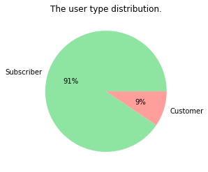

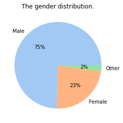

```
Number of users by age. The average age is 34 years.
```

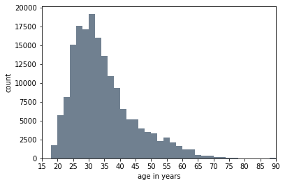

## What does the duration and frequency of the bike rental tell us?

> - Duration of the trips.
> - User per weekday and hour.
> - Duration per weekday for user types and member gender.

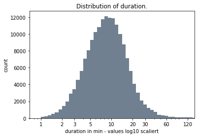

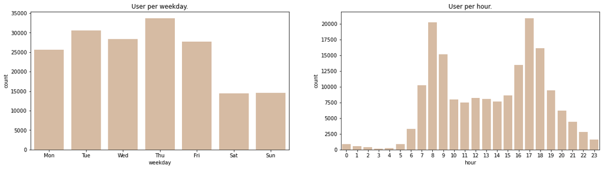

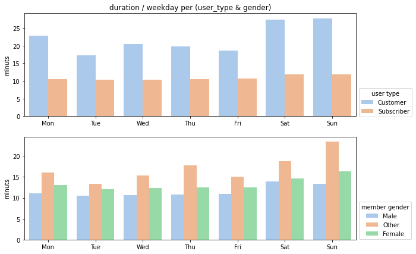